# Independence and sufficiency

Julia Fukuyama

Simulation-Based Inference · Lecture 14

## Today

Trying again with independence/sufficiency visualization and checks

- What does independence look like for two categorical variables? (mosaic plots)
- What does independence look like for two continuous variables?
- Same questions for conditional independence
- What if we have more than two variables? (high-dimensional visualization + random projections)

## Independent random variables

Recall from Lecture 2: random variables are **independent** if probabilities of simultaneous events can be obtained by multiplying their separate probabilities.

For two random variables, this means

$$P(X\in A,\ Y\in B)=P(X\in A)P(Y\in B)$$

for every pair of appropriate sets $A$ and $B$.

It is not a bad approximation to think of $A$ and $B$ as being intervals for continuous random variables and individual outcomes for categorical random variables.

## Independence/dependence for categorical variables

If $X$ and $Y$ take values in finite/countable sets, we can choose $A=\{x\}$ and $B=\{y\}$.

Independence means

$$P(X=x,Y=y)=P(X=x)P(Y=y)$$

for every pair of categories.

For example, if $P(X=1)=P(Y=1)=1/2$, independence requires $P(X=1,Y=1)=1/4$.

## Visualizing categorical random variables: Mosaic plot

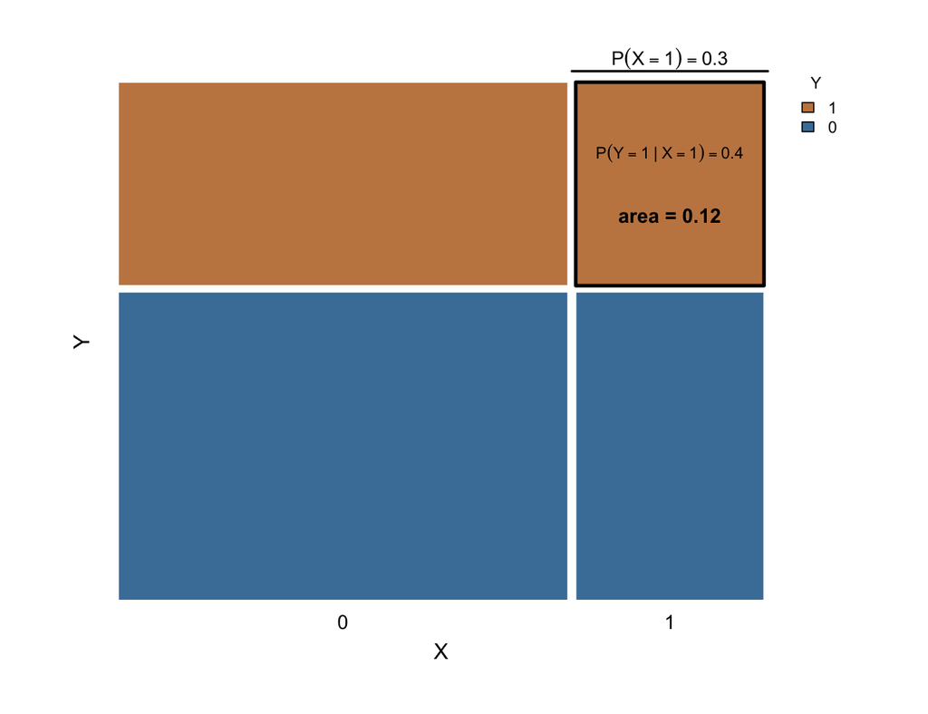

Each column represents a category of $X$.

Within each column, the boxes represent categories of $Y$.

The **area** of the $(x,y)$ box is the fraction of observations with $X=x$ and $Y=y$.

## Width, height, and area

For the box corresponding to $X=x$ and $Y=y$:

| Part of the box | Probability represented |
| --- | --- |
| Column width | $P(X=x)$ |
| Height within the column | $P(Y=y\mid X=x)$ |
| Area | $P(X=x,Y=y)$ |

The geometry follows the probability identity

$$P(X=x,Y=y)=P(X=x)P(Y=y\mid X=x).$$

## A mosaic under independence

Independence implies

$$P(Y=y\mid X=x)=P(Y=y)$$

whenever $P(X=x)>0$.

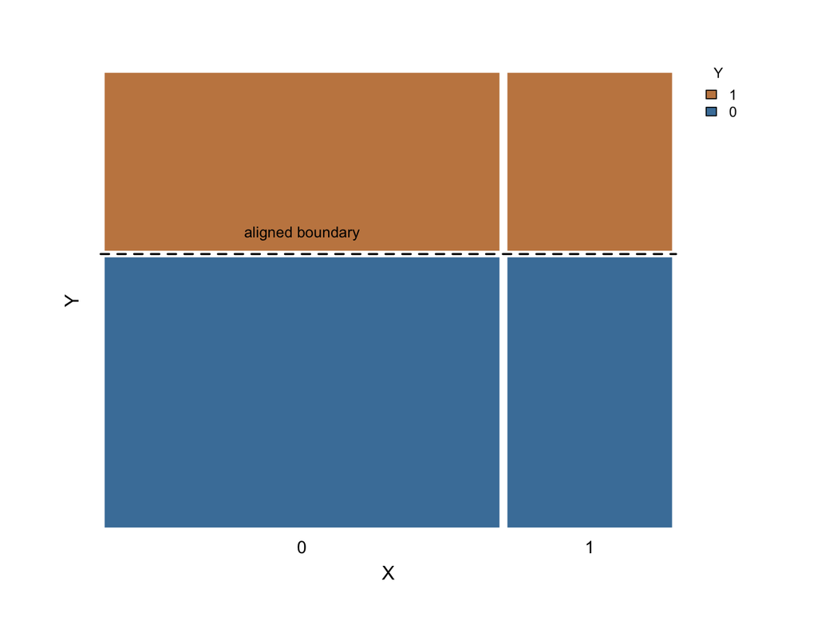

The proportions of the $Y$-categories are the same in every column, so the horizontal boundaries line up.

The boxes can still have different areas.

## A mosaic showing dependence

Everyone aboard the Titanic, by sex ($X$) and survival ($Y$).

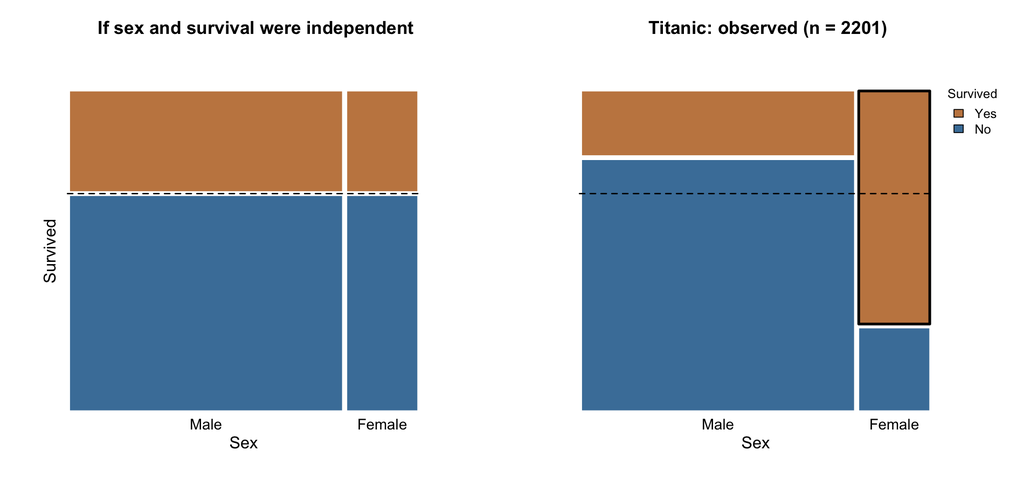

The distribution of $Y$ changes between the $X$-categories.

Knowing $X$ tells us something about $Y$.

## A mosaic plot of simulated independent data

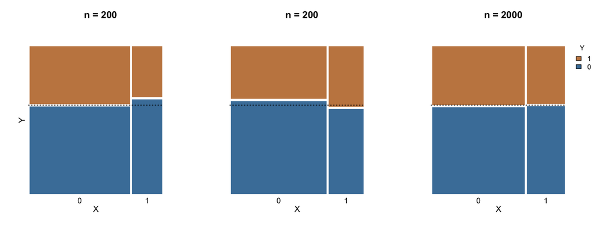

In a finite sample, the observed proportions will differ a little from one column to another.

We can simulate independent samples to see how much variation to expect.

## Independence/dependence for continuous variables

Flipper length ($X$) and body mass ($Y$) for 342 penguins near Palmer Station, Antarctica.

| Pair | How it is made |
| --- | --- |
| As measured | Each penguin’s own flipper length and body mass |
| Shuffled | Body masses randomly reassigned among the penguins |

Shuffling keeps both lists of values exactly, so $X$ and $Y$ have the same distributions in both pairs.

Shuffling makes the pair independent. Their joint distributions differ.

## Scatterplots of the two pairs

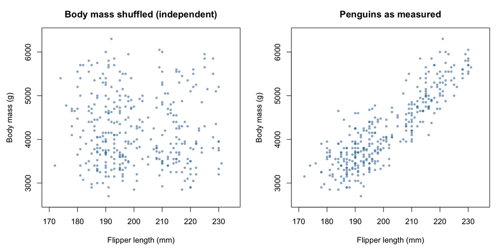

For the independent pair, knowing approximately where $X$ lies does not change the distribution we expect for $Y$.

For the dependent pair, the distribution of $Y$ moves upward as $X$ increases.

How can we connect these pictures to the definition of independence?

## Option 1: Discretize both variables and make a mosaic plot

Divide each axis into intervals $A_1,\ldots,A_4$ and $B_1,\ldots,B_4$.

Record the interval containing each observation:

$$X_{\mathrm{bin}}=i\quad\text{if }X\in A_i,
\qquad
Y_{\mathrm{bin}}=j\quad\text{if }Y\in B_j.$$

Now we have two categorical variables, so we can make a mosaic.

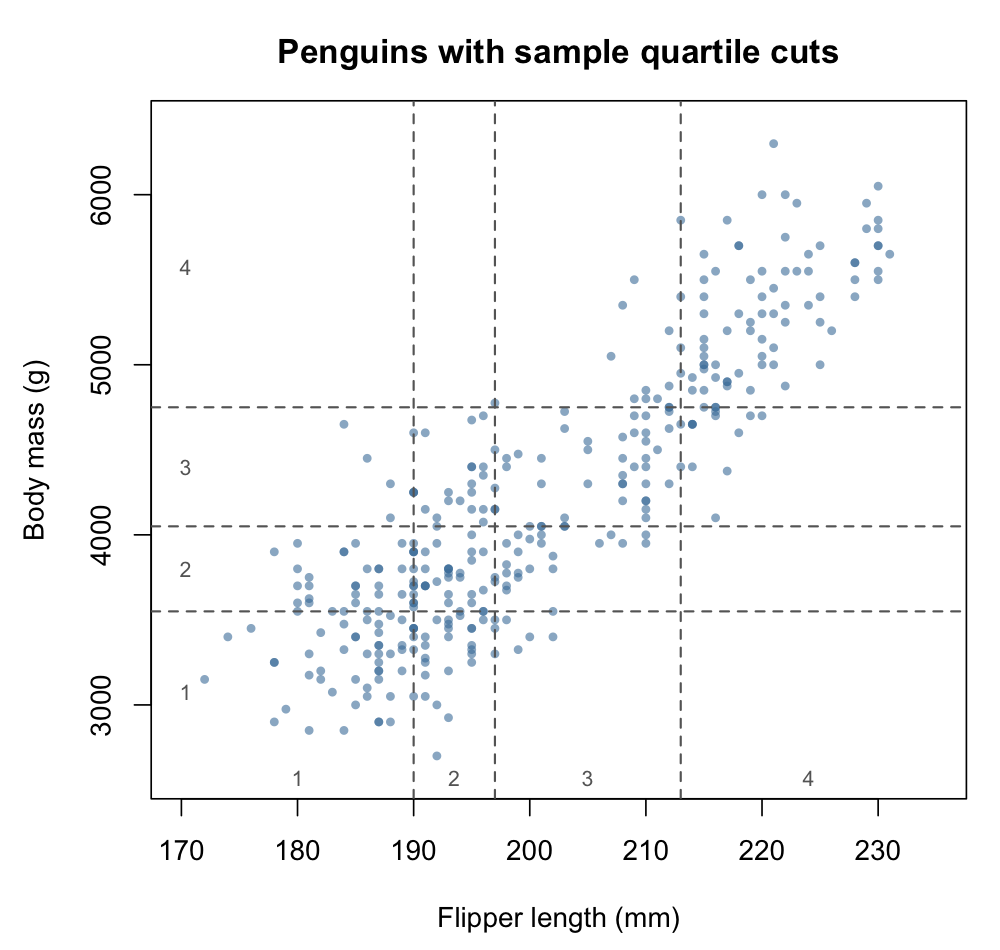

## What independence entails for the boxes

Independence means

$$P(X\in A_i,Y\in B_j)=P(X\in A_i)P(Y\in B_j).$$

Each interval holds about a quarter of the penguins, so each box should contain about $1/16$ of them.

Let’s check.

## The independent pair, discretized

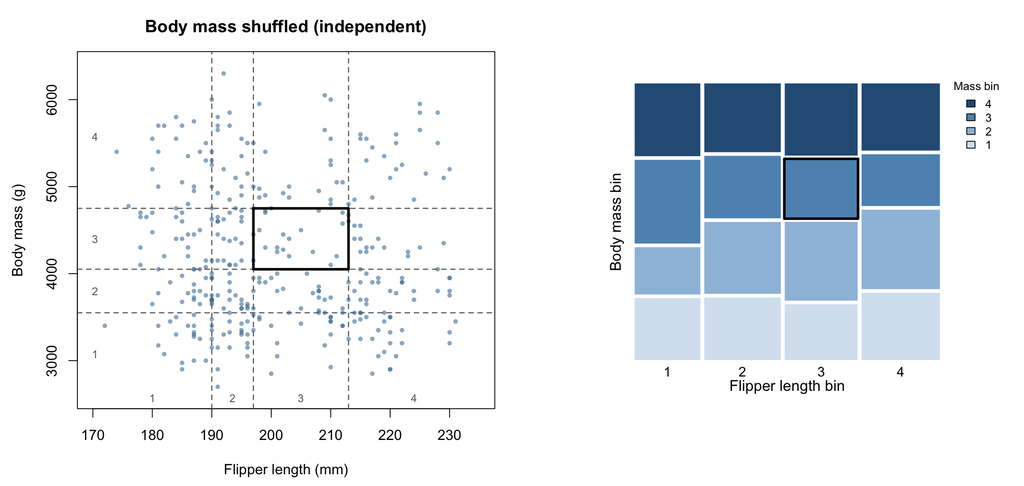

Each mosaic box represents a rectangle in the original scatterplot:

$$\{X\in A_i,\ Y\in B_j\}.$$

## The dependent pair, discretized

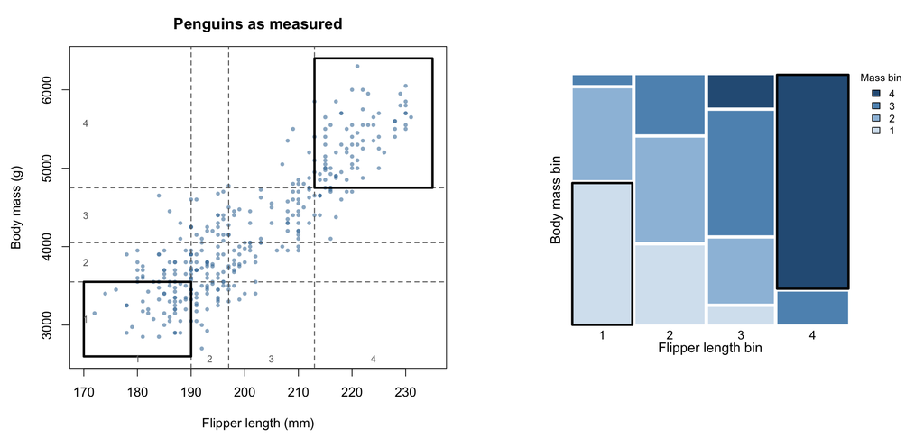

The marginal distributions are exactly the same as before.

But observations concentrate in boxes where $X$ and $Y$ are both low or both high.

The conditional proportions change across the mosaic columns.

## Notes

- How we read the mosaic for a discretized continuous variable

| Part of the mosaic box | Probability represented |
| --- | --- |
| Column width | $P(X\in A_i)$ |
| Height within the column | $P(Y\in B_j\mid X\in A_i)$ |
| Area | $P(X\in A_i,Y\in B_j)$ |

- Under independence, every column has the same conditional proportions.
- A coarse set of bins can hide dependence. The definition must hold for **every** pair of sets, not just the bins in one plot.
- The above is not possible to check exhaustively with finite data.

## Option 2: Discretize only one variable and visualize the distribution of the other

Instead of categorizing $Y$, make a histogram of its values within each $X$-interval.

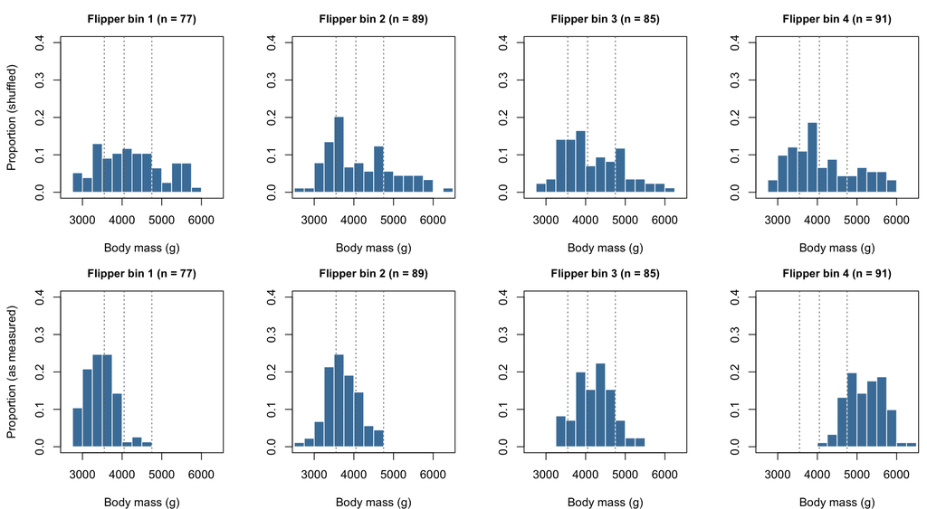

Each panel approximates $Y \mid X \in A_i$.

If $X$ and $Y$ are independent, the distributions shouldn’t change with $A_i$.

If $X$ and $Y$ are dependent, the distributions will change with $A_i$.

## The same information shown a different way

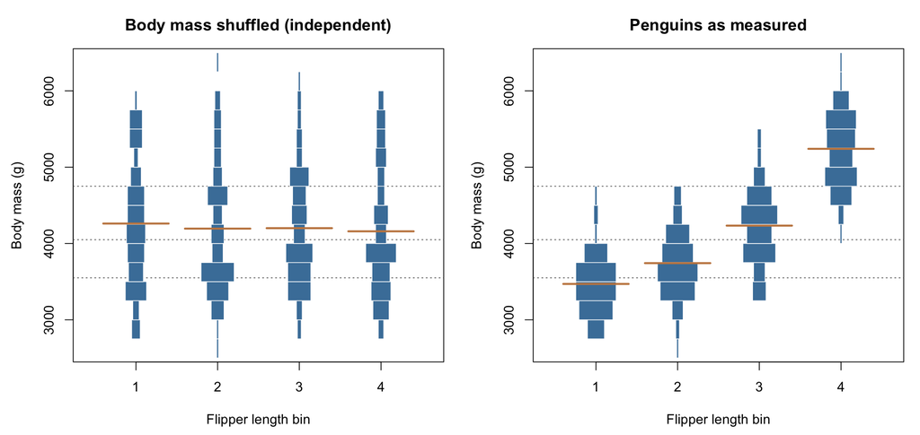

Each strip (a mirrored histogram) summarizes the distribution of $Y$ in one vertical strip of the scatterplot.

Under independence, the histograms should agree in location, spread, and shape.

A sloping mean is one way to see dependence. Changes in spread or shape also count.

## Option 3: Look at the scatterplot

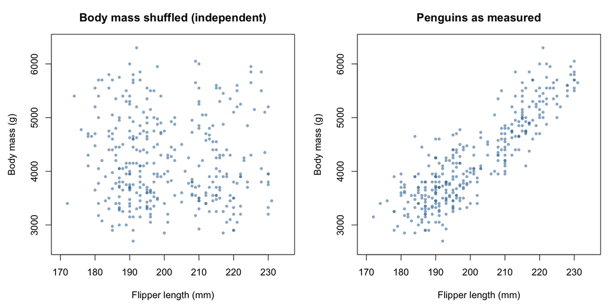

Look at individual strips of the $x$-axis variable. Does the distribution of the $y$-axis variable look the same in each?

## Conditional independence

$X$ and $Y$ are **conditionally independent given $Z$** if

$$\begin{aligned}
&P(X\in A,Y\in B\mid Z=z)\\
&\qquad=P(X\in A\mid Z=z)P(Y\in B\mid Z=z)
\end{aligned}$$

for every pair of sets $A,B$ and almost every conditioning value $z$.

We write $X\perp Y\mid Z$.

After fixing $Z$, knowing $X$ does not change the distribution of $Y$.

## Visualizing conditional distributions

Recall how we simulated conditional distributions:

- Generate joint outcomes $(X,Y,Z)$.
- Keep only those satisfying the condition.
- Study distributions within that collection.

Therefore:

- To inspect $(X,Y)\mid Z=z$, subset to observations with $Z=z$ and visualize $X$ and $Y$ on that subset.
- For continuous variables, we usually subset to observations with $Z \approx z$.
- We can use the plots from before on the subset.

## Conditioning on a categorical variable, penguin example

Return to the discretized penguin measurements:

- $X$: flipper length, cut into thirds within the species.
- $Y$: body mass, cut into thirds within the species.
- $Z$: species.

Suppose we want to know about the distribution $(X, Y) \mid Z = \text{Gentoo}$

Conditional independence predicts aligned horizontal boundaries within that species.

## Conditioning: keep the Gentoo rows

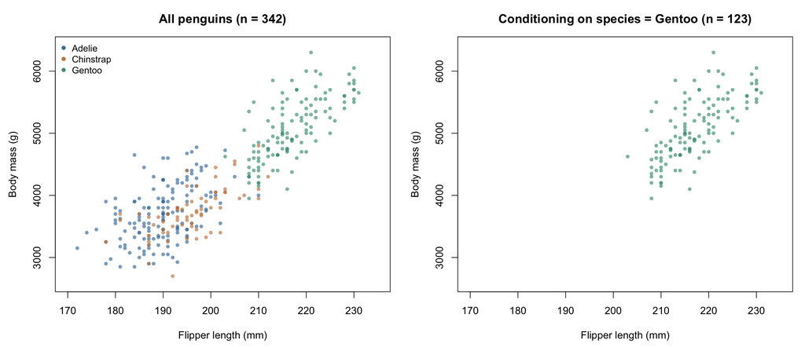

Conditioning on $Z = \text{Gentoo}$ means throwing away every other row.

## The Gentoo rows, discretized

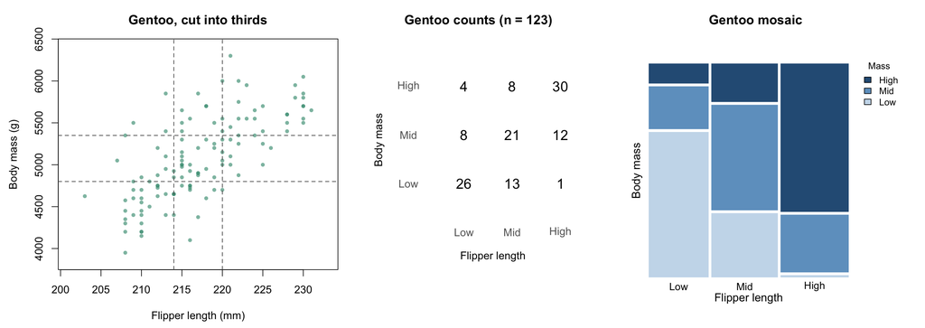

Does the distribution of body-mass categories change across flipper-length categories?

If it does, fixing species has not removed the relationship.

## Comparing conditional distributions

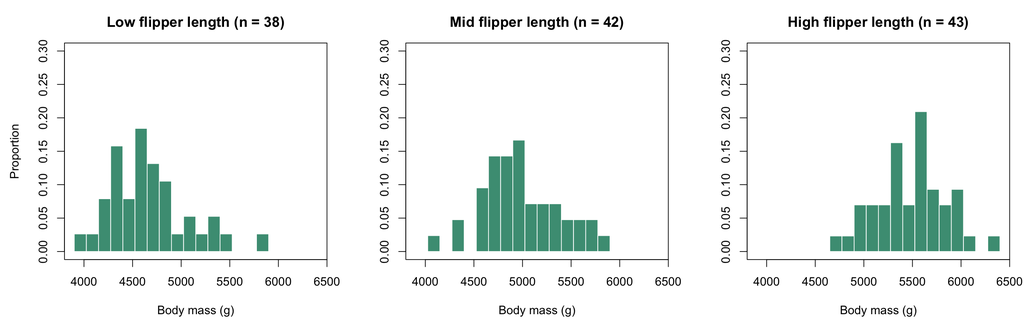

Each histogram represents

$$Y\mid X\in A_i,\ Z=\text{Gentoo}.$$

Under conditional independence, these distributions should agree across the $X$-intervals.

The common distribution may be different for a different species.

## How do we condition on a continuous variable?

When the conditioning variable was categorical (species), we can select rows with exactly $Z=z$.

With a continuously distributed conditioning variable $Z$, a finite simulation bank will not contain rows with exactly a chosen value.

Instead, we might keep a range:

$$z_0-h<Z<z_0+h.$$

That range combines different values of $Z$.

## Example: Packing and posting a parcel

Consider a simplified warehouse simulator:

- $Z$: the parcel’s weight.
- $X$: the time needed to pack it.
- $Y$: the postage charge.

Heavier parcels tend to take longer to pack and cost more to post.

At a fixed weight, the simulator generates the extra packing time and extra postage charges independently.

Thus, in this model, $X\perp Y\mid Z$.

## Parcels in a weight range

Suppose we just have data from this model and don’t know how it was generated.

Suppose further that we want to know whether $X$ and $Y$ are conditionally independent given $Z$.

To do so, we investigate the distribution of $(X, Y) \mid Z$.

We do so by plotting observations from the simulation bank that satisfy $Z \in (z_0 - h, z_0 + h)$.

We’ll start with $z_0 = 2$ and $h = 1, .3, .05$.

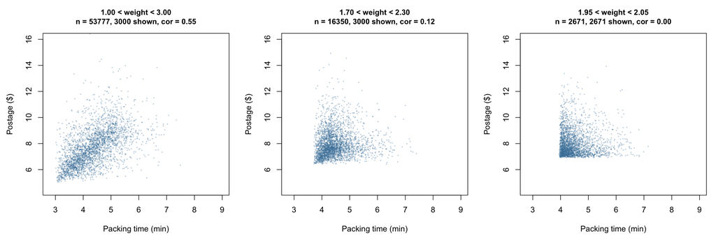

## Postage within packing-time strips, $h = 1$

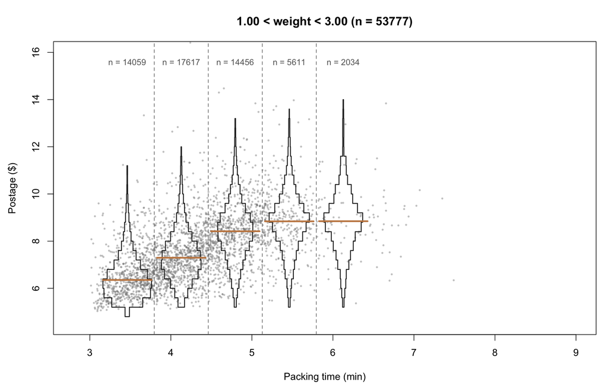

Postage shifts upward from strip to strip.

## Postage within packing-time strips, $h = 1$

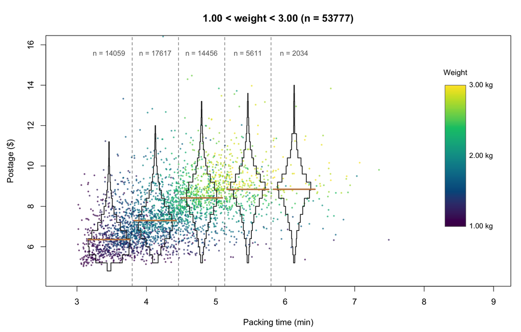

Color by weight: the strips differ because they hold parcels of different weights.

## Postage within packing-time strips, $h = 0.3$

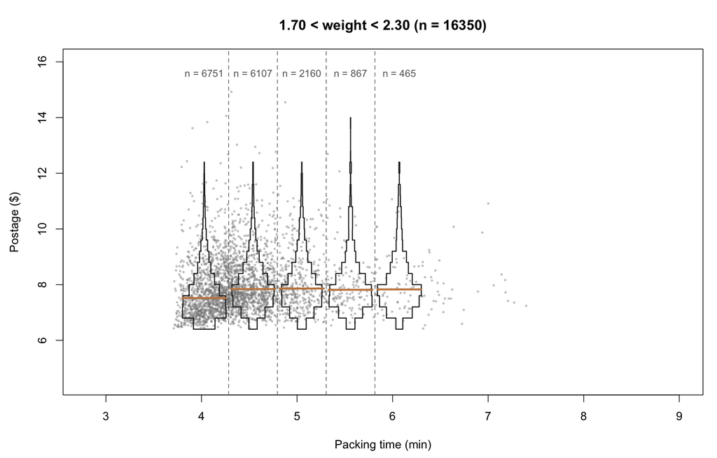

A smaller shift remains, mostly between the first strip and the rest.

## Postage within packing-time strips, $h = 0.3$

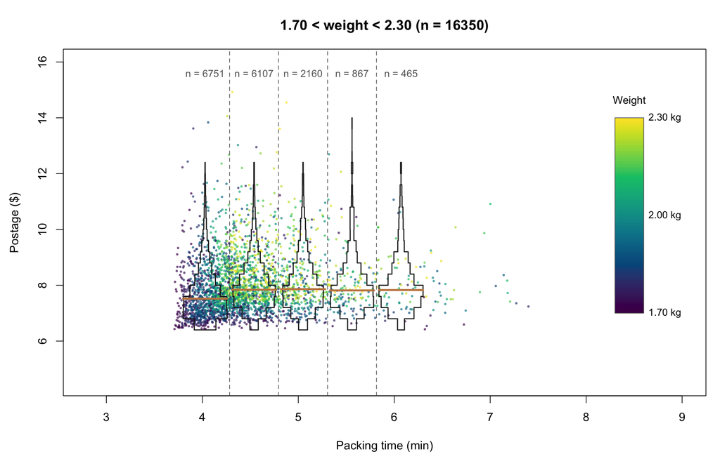

The first strip holds mostly the lighter parcels in the range, which is where the remaining shift comes from.

## Postage within packing-time strips, $h = 0.05$

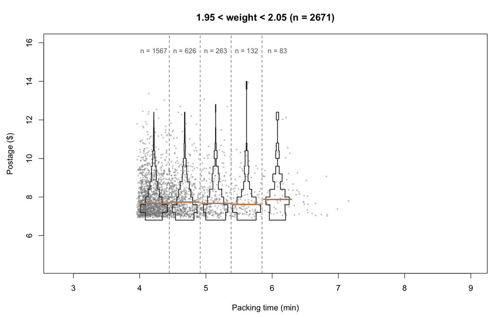

The distributions agree, up to noise in the sparse right-hand strips.

## Postage within packing-time strips, $h = 0.05$

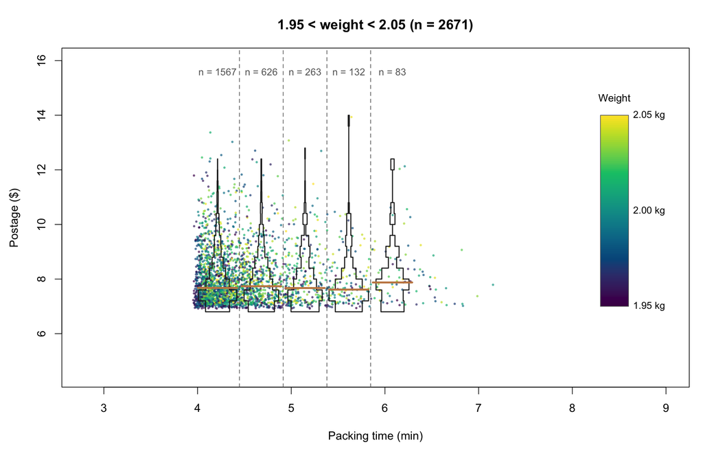

Light and heavy parcels within the range are mixed across all the strips.

## Interpreting a conditional-independence plot

When we filter to a range, a visible relationship can come from dependence remaining at a fixed conditioning value, or from mixing conditioning values.

Before interpreting the plot, ask:

- What exactly did we condition on?
- How much does the conditioning variable still vary within the retained collection?
- What happens when we narrow the range, and how many observations remain?

## Next big problem

We have seen how to check for independence between two random variables and how to check for conditional independence between two random variables given a third.

What if we want to check for independence/conditional independence between a random vector (e.g. a whole dataset) and a random variable?

Motivation: For ABC, wanted to know whether $S(X)$ is a sufficient statistic, (that is, whether $X$ and $\theta$ were conditionally independent given a statistic $S(X)$).

## Independence with a vector

Suppose we want to know whether $\theta$ is independent of a vector

$$\mathbf X=(X_1,\ldots,X_p).$$

We could plot $\theta$ against each coordinate.

But $\theta$ can be independent of every individual coordinate and still depend on the combination.

$$\theta\perp X_j\text{ for every }j
\quad\text{does not imply}\quad
\theta\perp\mathbf X.$$

## Example: Ten days of rain

Recall our weather model from before.

Let $X_t=1$ if day $t$ is rainy and $X_t=0$ if it is dry.

- Day 1 is equally likely to be rainy or dry.
- Each subsequent day repeats the previous day’s weather with probability $\theta$.
- Otherwise, the weather switches.

Each simulation produces a vector

$$\mathbf X=(X_1,\ldots,X_{10}).$$

Large $\theta$ gives long wet and dry spells. Small $\theta$ gives frequent switches.

## Simulated weather sequences

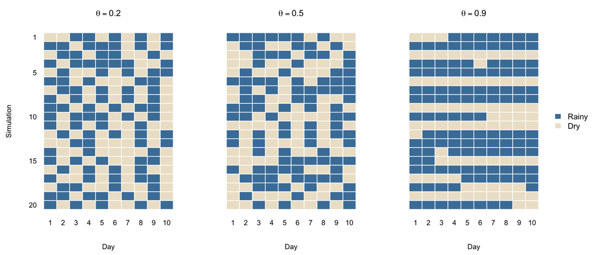

Each row is one simulation. Each column is one day.

## $X_i$ and $\theta$ are independent

Suppose we plot $\theta$ against $X_1$, then $X_2$, and so on.

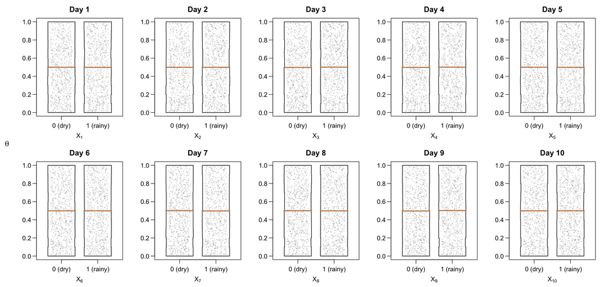

On every day, $\theta$ has the same distribution among the dry and the rainy simulations.

## But the entire vector $\mathbf X$ is not independent of $\theta$

Create a “total rainy days” statistic: $R(\mathbf X)=X_1+\cdots+X_{10}.$

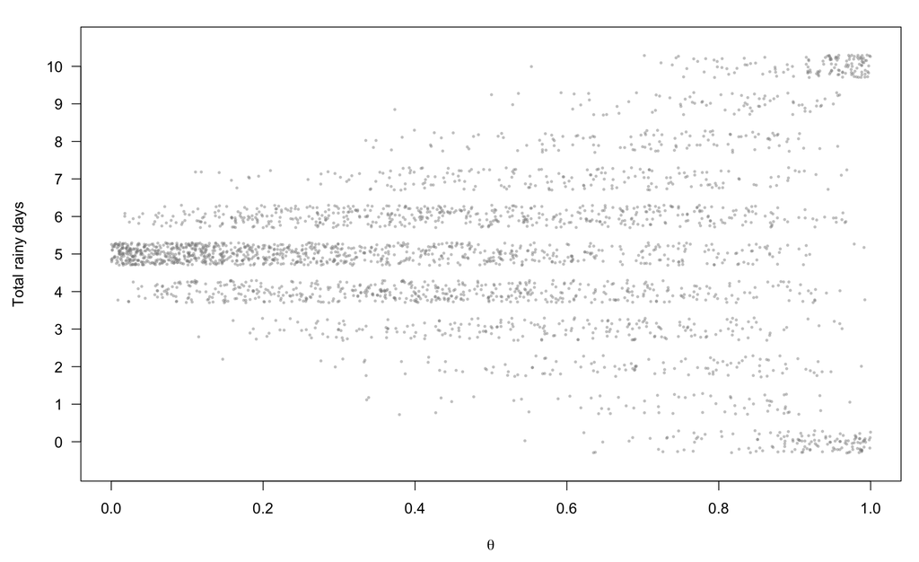

## But the entire vector $\mathbf X$ is not independent of $\theta$

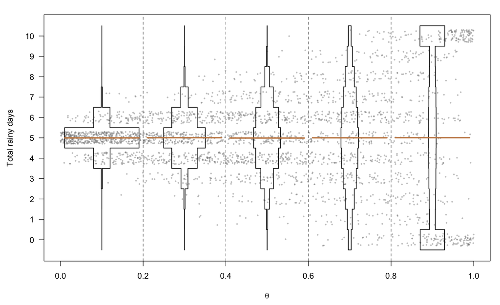

The distribution of the total changes with $\theta$.

## What the combination tells us

If $\theta$ were independent of $\mathbf X$, it would also be independent of every function of $\mathbf X$.

But $R(\mathbf X)$ has a distribution that changes with $\theta$.

Therefore,

$$\theta\not\perp\mathbf X,
\qquad\text{even though}\qquad
\theta\perp X_t\text{ for every }t.$$

Checking individual coordinates can miss information in how they vary together.

## Other combinations of the coordinates

The total is a linear combination:

$$R(\mathbf X)=\mathbf 1^\mathsf T\mathbf X.$$

More generally, we could inspect

$$h_{\mathbf a}(\mathbf X)=a_1X_1+\cdots+a_{10}X_{10}.$$

We may not know which weights reveal a change in distribution.

One option is to try randomly chosen weights and compare the resulting distributions across values of $\theta$.

## Related: Tours

A **tour** smoothly changes the projection direction so that we can inspect many views of the same data.

Some views reveal structure that others conceal.

[Example: Cook and Laa, *Interactively Exploring High-Dimensional Data and Models in R*, Chapter 1](https://dicook.github.io/mulgar_book/1-intro.html)

## A tour for an independence question

To examine whether $Y\perp\mathbf X$, keep $Y$ on one axis and change the projection on the other:

$$\text{plot }Y\text{ against }T_a=a^\top\mathbf X.$$

Under independence, the distribution of $T_a$ should stay the same across values of $Y$, for every direction $a$.

We look for changes in location, spread, or shape.

## Random projections and numerical checks

We can inspect these views visually, or measure dependence numerically.

1. Draw a direction $a$ and compute $T_a=a^\top\mathbf X$.
2. Compare the distributions of $T_a$ across values of $Y$.
3. Repeat for other directions.

For example, discretize $T_a$ and $Y$, then compare joint cell proportions with products of marginal proportions.

## Why inspect projections?

For numeric vectors,

$$Y\perp\mathbf X
\quad\Longleftrightarrow\quad
Y\perp a^\top\mathbf X\text{ for every direction }a.$$

All one-dimensional projections determine a multivariate distribution.

A finite collection of plots or numerical checks can still miss dependence, especially with limited data.

## Returning to sufficiency

For a sufficiency check, first restrict simulations to the observed summary, or a neighborhood of it.

Then inspect whether any projection of the remaining data is related to the parameter, either graphically using a tour or numerically using random projections:

$$\theta\perp a^\top\mathbf X\mid S(\mathbf X).$$

Both inherit the earlier limitations of approximate conditioning and finite samples.

## What we saw

- How to visualize independence/dependence of random variables using mosaic plots or scatter plots.
- How to visualize conditional independence/dependence of random variables.
- Dependence of a random vector $\mathbf X = (X_1,\ldots, X_p)$ and another random quantity cannot be checked using only the individual coordinates $X_i$.
- We can use can use random projections or tours for independence of random vectors, but it’s always possible to miss something.
- [Cook and Laa, *Interactively Exploring High-Dimensional Data and Models in R*, Chapter 1](https://dicook.github.io/mulgar_book/1-intro.html). Projections and tours.